# Workshop Week 2

Author

Affiliation

STAT5003

School of Mathematics and Statistics

## Learning Outcomes

**Important**

1. **Initiate an R Project**:
   - Create and organise an R project, including subfolders for datasets and output files.
   - Create a reproducible report via an RMarkdown file.
2. **File I/O**:
   - Use `read.csv` to read data from CSV files into R.
   - Use `write.csv` to write data from R to CSV files.
3. **Numerical Summaries**:
   - Use `summary()` to get basic statistics.
4. **Graphical Summaries**:
   - Use `boxplot`, `plot` or `ggplot` to visualize data.
5. **Data Manipulation**:
   - Use `subset` to filter and subset data based on given conditions.

## Initiate an R Project

Follow [the instructional video](https://canvas.sydney.edu.au/courses/68404/pages/how-to-start-an-rproject-slash-rmarkdown?module_item_id=2798217) to ensure that you are currently working within an R project named **STAT5003**. Make sure `Sonar.csv` has been downloaded from Canvas and saved in a folder named **datasets**. Additionally, have an RMarkdown file open named **wk2_workshop.rmd** and be ready to continue the workshop questions in this file.

## File I/O

**Read**

Modifying the below code for reading in the `Sonar.csv` file into `R` and assign it to the object called `sonar`.

```r
library(tidyverse)
## install.packages("here") # use this function to install a new package, this action needs to be done once
library(here) # load package, the `here` package simplifies the process of constructing file paths in R projects.

cereal <- read.csv(here("datasets", "Cereal.csv"))
```

```r
library(tidyverse)
## install.packages("here") # use this function to install a new package, this action needs to be done once
library(here) # load package, the `here` package simplifies the process of constructing file paths in R projects.

sonar <- read.csv(here("datasets", "Sonar.csv"))
```

**Data frames**

1. Use `head(sonar)` to view the first few lines and `class(sonar)` to confirm it’s a data frame.

```r
head(sonar)
```

```
  X     V1     V2     V3     V4     V5     V6     V7     V8     V9    V10
1 1 0.0200 0.0371 0.0428 0.0207 0.0954 0.0986 0.1539 0.1601 0.3109 0.2111
2 2 0.0453 0.0523 0.0843 0.0689 0.1183 0.2583 0.2156 0.3481 0.3337 0.2872
3 3 0.0262 0.0582 0.1099 0.1083 0.0974 0.2280 0.2431 0.3771 0.5598 0.6194
4 4 0.0100 0.0171 0.0623 0.0205 0.0205 0.0368 0.1098 0.1276 0.0598 0.1264
5 5 0.0762 0.0666 0.0481 0.0394 0.0590 0.0649 0.1209 0.2467 0.3564 0.4459
6 6 0.0286 0.0453 0.0277 0.0174 0.0384 0.0990 0.1201 0.1833 0.2105 0.3039
     V11    V12    V13    V14    V15    V16    V17    V18    V19    V20    V21
1 0.1609 0.1582 0.2238 0.0645 0.0660 0.2273 0.3100 0.2999 0.5078 0.4797 0.5783
2 0.4918 0.6552 0.6919 0.7797 0.7464 0.9444 1.0000 0.8874 0.8024 0.7818 0.5212
3 0.6333 0.7060 0.5544 0.5320 0.6479 0.6931 0.6759 0.7551 0.8929 0.8619 0.7974
4 0.0881 0.1992 0.0184 0.2261 0.1729 0.2131 0.0693 0.2281 0.4060 0.3973 0.2741
5 0.4152 0.3952 0.4256 0.4135 0.4528 0.5326 0.7306 0.6193 0.2032 0.4636 0.4148
6 0.2988 0.4250 0.6343 0.8198 1.0000 0.9988 0.9508 0.9025 0.7234 0.5122 0.2074
     V22    V23    V24    V25    V26    V27    V28    V29    V30    V31    V32
```

[output cut: 27 more lines]

```r
head(sonar, n = 10) # to change the default of showing the first six lines to the first 10 observations
```

```
    X     V1     V2     V3     V4     V5     V6     V7     V8     V9    V10
1   1 0.0200 0.0371 0.0428 0.0207 0.0954 0.0986 0.1539 0.1601 0.3109 0.2111
2   2 0.0453 0.0523 0.0843 0.0689 0.1183 0.2583 0.2156 0.3481 0.3337 0.2872
3   3 0.0262 0.0582 0.1099 0.1083 0.0974 0.2280 0.2431 0.3771 0.5598 0.6194
4   4 0.0100 0.0171 0.0623 0.0205 0.0205 0.0368 0.1098 0.1276 0.0598 0.1264
5   5 0.0762 0.0666 0.0481 0.0394 0.0590 0.0649 0.1209 0.2467 0.3564 0.4459
6   6 0.0286 0.0453 0.0277 0.0174 0.0384 0.0990 0.1201 0.1833 0.2105 0.3039
7   7 0.0317 0.0956 0.1321 0.1408 0.1674 0.1710 0.0731 0.1401 0.2083 0.3513
8   8 0.0519 0.0548 0.0842 0.0319 0.1158 0.0922 0.1027 0.0613 0.1465 0.2838
9   9 0.0223 0.0375 0.0484 0.0475 0.0647 0.0591 0.0753 0.0098 0.0684 0.1487
10 10 0.0164 0.0173 0.0347 0.0070 0.0187 0.0671 0.1056 0.0697 0.0962 0.0251
      V11    V12    V13    V14    V15    V16    V17    V18    V19    V20    V21
1  0.1609 0.1582 0.2238 0.0645 0.0660 0.2273 0.3100 0.2999 0.5078 0.4797 0.5783
2  0.4918 0.6552 0.6919 0.7797 0.7464 0.9444 1.0000 0.8874 0.8024 0.7818 0.5212
3  0.6333 0.7060 0.5544 0.5320 0.6479 0.6931 0.6759 0.7551 0.8929 0.8619 0.7974
```

[output cut: 51 more lines]

```r
class(sonar)
```

```
[1] "data.frame"
```

2. Use `colnames(sonar)` for column names and `dim(sonar)` or `nrow(sonar)` for the number of rows.

```r
colnames(sonar)
```

```
 [1] "X"     "V1"    "V2"    "V3"    "V4"    "V5"    "V6"    "V7"    "V8"
[10] "V9"    "V10"   "V11"   "V12"   "V13"   "V14"   "V15"   "V16"   "V17"
[19] "V18"   "V19"   "V20"   "V21"   "V22"   "V23"   "V24"   "V25"   "V26"
[28] "V27"   "V28"   "V29"   "V30"   "V31"   "V32"   "V33"   "V34"   "V35"
[37] "V36"   "V37"   "V38"   "V39"   "V40"   "V41"   "V42"   "V43"   "V44"
[46] "V45"   "V46"   "V47"   "V48"   "V49"   "V50"   "V51"   "V52"   "V53"
[55] "V54"   "V55"   "V56"   "V57"   "V58"   "V59"   "V60"   "Class"
```

```r
dim(sonar)
```

```
[1] 208  62
```

```r
nrow(sonar)
```

```
[1] 208
```

More advanced version using tidyverse syntax

```r
sonar |> colnames()
```

```
 [1] "X"     "V1"    "V2"    "V3"    "V4"    "V5"    "V6"    "V7"    "V8"
[10] "V9"    "V10"   "V11"   "V12"   "V13"   "V14"   "V15"   "V16"   "V17"
[19] "V18"   "V19"   "V20"   "V21"   "V22"   "V23"   "V24"   "V25"   "V26"
[28] "V27"   "V28"   "V29"   "V30"   "V31"   "V32"   "V33"   "V34"   "V35"
[37] "V36"   "V37"   "V38"   "V39"   "V40"   "V41"   "V42"   "V43"   "V44"
[46] "V45"   "V46"   "V47"   "V48"   "V49"   "V50"   "V51"   "V52"   "V53"
[55] "V54"   "V55"   "V56"   "V57"   "V58"   "V59"   "V60"   "Class"
```

```r
sonar |> nrow()
```

```
[1] 208
```

```r
sonar |> dim()
```

```
[1] 208  62
```

3. Extract the `Class` column and assign it to an object named `target`

```r
# There are two ways of doing it
target <- sonar$Class

target <- sonar[["Class"]]
```

```r
# Tidyverse version
target <- sonar |> select(Class)
```

4. To create a new data frame called `mine` from the `sonar` dataset that contains observations where the `Class` is M (metal cylinder), you can modify the `cereal` example

```r
Kelloggs <- subset(cereal, mfr == "K")

## if you are confident, you can use the `filter` function
Kelloggs <- cereal |> filter(mfr == "K")
```

```r
library(tidyverse)
mine <- sonar |> filter(Class == "M")
```

**Factors**

1. Load the `sonar` data again with the `read.csv` command again. This time, use the optional argument, `stringsAsFactors = TRUE`. The `Class` column is now a factor. Check that this is true.

```r
# converting character columns to factors.
sonar_with_factors <- read.csv(here("datasets","Sonar.csv"), stringsAsFactors = TRUE)

# Shows the structure of 'sonar_with_factors', indicating that only character columns are converted to factors.

## omit printing out the code as the results are too long
# str(sonar_with_factors)

# Shows the structure of the original 'sonar' data frame.
## omit printing out the code as the results are too long
# str(sonar)
```

2. How many levels are there in `Class`? (use the functions `levels` or `nlevels`) - levels will only count FACTORS not CHARACTER strings

```r
levels(sonar_with_factors$Class)
```

```
[1] "M" "R"
```

```r
# alternatively, using the double square brackets to extract the variable
levels(sonar_with_factors[["Class"]])
```

```
[1] "M" "R"
```

```r
## or
nlevels(sonar_with_factors$Class)
```

```
[1] 2
```

```r
## or
str(sonar_with_factors$Class)
```

```
 Factor w/ 2 levels "M","R": 2 2 2 2 2 2 2 2 2 2 ...
```

**Vectors**

1. Extract the `V1` into a new vector called `v1`. You can use `is.vector` to check its data structure

```r
v1 <- sonar$V1

v1 <- sonar[["V1"]]

## tidyverse
v1 <- sonar |> select(V1) |> pull()

is.vector(v1)
```

```
[1] TRUE
```

2. Use `length` to find out how many elements are there in `v1`?

```r
length(v1)
```

```
[1] 208
```

3. Extract the 5th to the 10th element from `v1`.

```r
v1[5:10]
```

```
[1] 0.0762 0.0286 0.0317 0.0519 0.0223 0.0164
```

4. The `c()` function in R is used to combine or concatenate values into a vector. It stands for **“combine”** or **“concatenate”**. Add a new observation **1.5** to `v1`, and calculate the length again.

```r
# Add the value 1.5 to the end of the 'v1' vector using the concatenate function 'c'.
v1 <- c(v1, 1.5) # c for concatenate

# Get the length of the 'v1' vector to see how many elements it contains.
length(v1)
```

```
[1] 209
```

**Matrix**

1. Use `as.matrix(sonar)` to convert the `sonar` data frame into a Matrix? Use `is.matrix` to check it is indeed a matrix.

```r
# Convert the 'sonar' data frame to a matrix.
sonar_matrix<- as.matrix(sonar)

# Check if 'sonar_matrix' is indeed a matrix.
is.matrix(sonar_matrix)
```

```
[1] TRUE
```

```r
str(sonar_matrix)
```

```
 chr [1:208, 1:62] "  1" "  2" "  3" "  4" "  5" "  6" "  7" "  8" "  9" ...
 - attr(*, "dimnames")=List of 2
  ..$ : NULL
  ..$ : chr [1:62] "X" "V1" "V2" "V3" ...
```

2. Using the `subset()` function and `select` to remove the `Class` column.

```r
sonar_remove <- subset(sonar, select = -Class)
```

## Numerical summary

**Summary**

1. Use the `summary` function to extract the median, 1st quartile and 3rd quartile data from the `V1` column in `sonar` data. Given its mean and median, what do you think of the shape of `V1` data distribution?

```r
summary(sonar$V1)
```

```
   Min. 1st Qu.  Median    Mean 3rd Qu.    Max.
0.00150 0.01335 0.02280 0.02916 0.03555 0.13710
```

Since the mean is greater than its median, we expect the data distribution for `V1` to be right skewed.

**Basic statistics**

2. Use `max()`, `min()`, `sd()`, `mean()` to find the max, min, standard deviation and mean of `V1.`

```r
max(sonar$V1)
```

```
[1] 0.1371
```

```r
min(sonar$V1)
```

```
[1] 0.0015
```

```r
sd(sonar$V1)
```

```
[1] 0.02299091
```

```r
mean(sonar$V1)
```

```
[1] 0.02916394
```

3. The `aggregate` function can be used to calculate `summary statistics` for a given level of a categorical variable. Below is an example code that demonstrates how to find the mean sodium for each mfr in the cereal data. Modify the code to find the **median** `V1` of each `Class`.

```r
aggregate(sodium ~ mfr, data = cereal, FUN = mean)
```

```r
#| echo: true
#| code-fold: true
#| message: false


aggregate(V1 ~ Class, data = sonar, FUN = median)
```

```
  Class     V1
1     M 0.0269
2     R 0.0201
```

```r
# Alternatively, in tidyverse select the 'V1' and 'Class' columns from the 'sonar' data frame, group by 'Class', and calculate the median content for each group.
sonar |>
    select(V1, Class) |>
    group_by(Class) |>
    summarise(med = median(V1))
```

```
# A tibble: 2 × 2
  Class    med
  <chr>  <dbl>
1 M     0.0269
2 R     0.0201
```

## Graphical summary

**Boxplot**

1. Make a boxplot of the `V1` against `Class` using `boxplot()`.

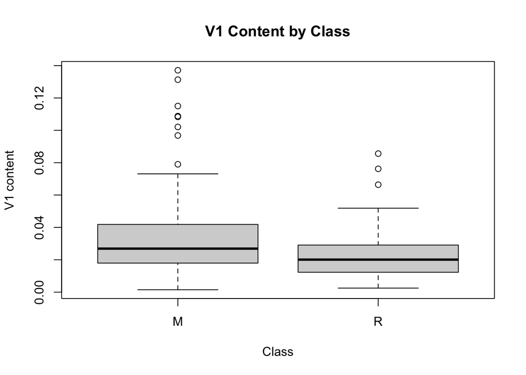

```r
# Create a boxplot of V1 content by Class using base R.
# labels for both axes and give a meaningful title
boxplot(V1 ~ Class, data = sonar,
        xlab = "Class", ylab = "V1 content", main = "V1 Content by Class")
```

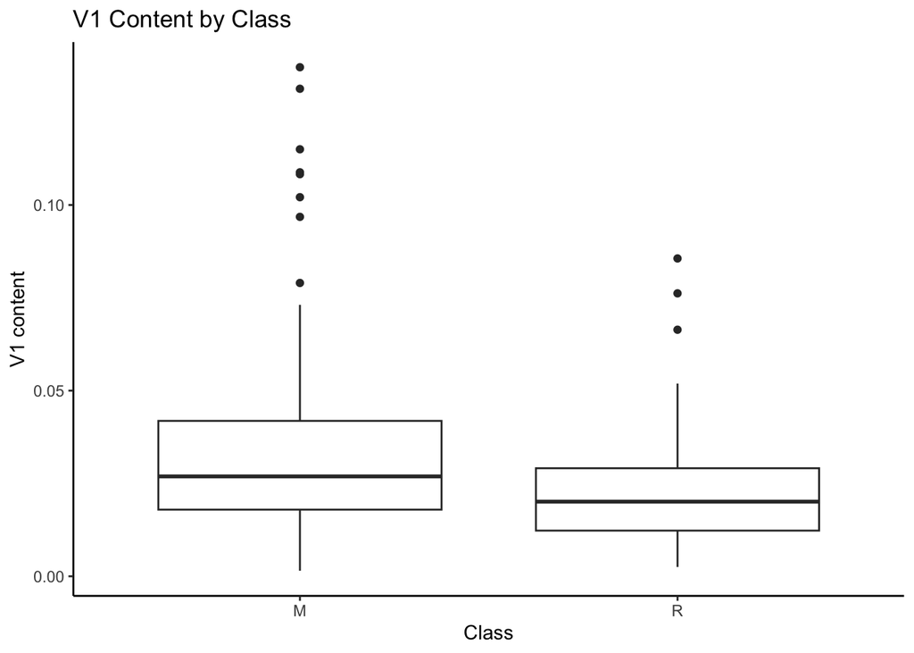

```r
# Using ggplot2.

sonar |>
  ggplot(aes(x = Class, y = V1)) +
  geom_boxplot() +
  theme_classic() +
  labs(x =  "Class", y = "V1 content") +
  ggtitle("V1 Content by Class")
```

**Scatter plot**

2. Plot `V2` against `V1` using `plot()`.

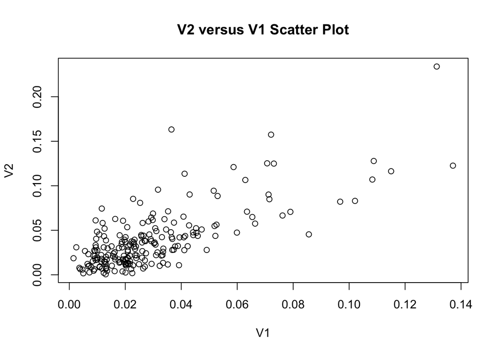

```r
# Create a scatter plot of calories versus V1 using base R.
# The plot has the title "Calories versus V1 Scatter Plot".
plot(V2 ~ V1, data = sonar, main = "V2 versus V1 Scatter Plot")
```

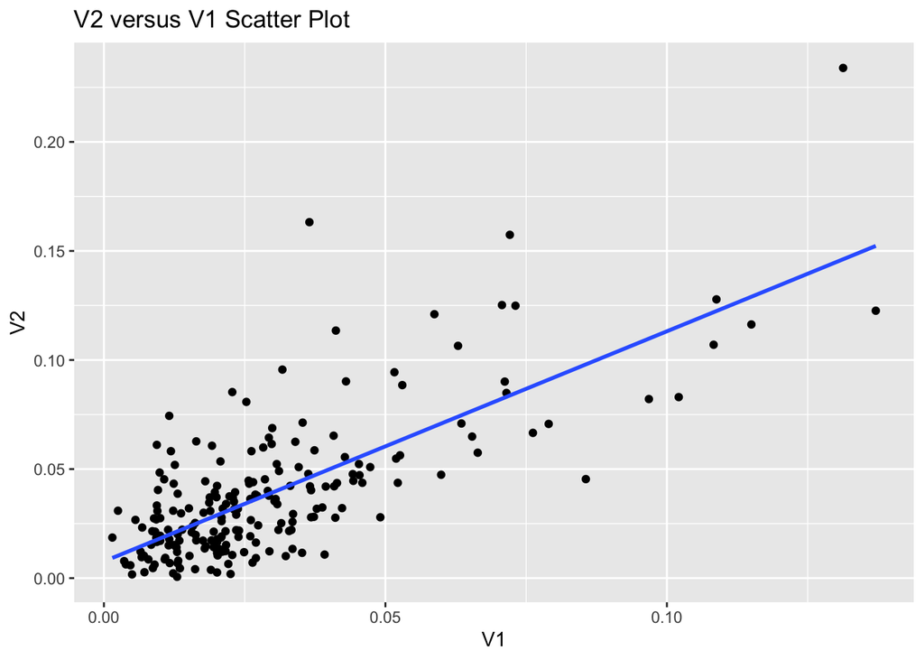

```r
# Create a scatter plot of calories versus V1 using ggplot2.
# Add a linear regression line without the confidence interval.
# The plot has the title "Calories versus V1 Scatter Plot".
sonar |>
  ggplot(aes(x = V1, y = V2)) +
  geom_point() +
  geom_smooth(method = "lm", se = FALSE) +
  labs(x =  "V1", y = "V2") +
  ggtitle("V2 versus V1 Scatter Plot")
```

**Write Data to File**

2. Use `write.csv` to write a data frame containing only the `M` (medal cylinder) observations to a file called `mine`.

```r
write.csv(mine, here("datasets", "mine.csv"))
```

## Extension Section: Boost Your R Programming Skills

Looking to give your R programming skills an extra boost? This section offers two powerful ways to supercharge your coding:

Note: This section is designed for students who have completed the above exercises. **It is not assessable.**

**Consolidation**

Complete the recommended course [Introduction to the Tidyverse](https://app.datacamp.com/groups/stat5003-s1-2025/assignments/326436) on DataCamp focussing on a powerful set of tools known as `Tidyverse`.

**Practice**

Re-do the above exercises using Tidyverse syntax to reinforce your learning and enhance your coding efficiency.